# Outlier Detection Techniques

# I. Outlier

## 1. Definition

An outlier is an observation that lies outside of the overall pattern of a distribution.

## 2. Cause

Outliers can be the results of:

- **Data entry errors**: Human mistakes can be made during data collection or data coding.
- **Measurement error**: Inadequate metric can render an observation obtrusive.
- **Sampling problem**: If an observation is from the subset of population other than that of interest, it may stand out from other observations.
- **Intentional**: In real life data, outliers are just expected to be. Sometimes we might want to mock such outliers either to test a detection method, or to make a robust model generous to outliers.
- **Natural variation**: More often than not, an outlier is not the result of an error, and may contain some novel insights.
- …and so on.

# II. Effect

## 1. On estimation

Outliers can greatly affect mean-like estimators. Consider following example.

```r
sample = c(1, 3, 4, 6, 7, 7, 9, 10)
mean(sample)
```

```
## [1] 5.875
```

Above sample does not include outlier. Its mean is 5.875, which is reasonable to eye-measure.

```r
sample1 = c(sample, 30)
mean(sample1)
```

```
## [1] 8.555556
```

Now let’s add an seemingly outlier of 30. It brings the average up to 8.56.

```r
sample2 = c(sample, 50)
mean(sample2)
```

```
## [1] 10.77778
```

What if an outlier is as large as 50? The average becomes 10.78.  
As can be seen from this example, outliers can affect estimators and deviate them away from the population of interest.

## 2. On prediction

Outliers can also affect the result of prediction. We usually want to predict in terms of general tendency, not taking special cases into account.

Consider following data, for example.

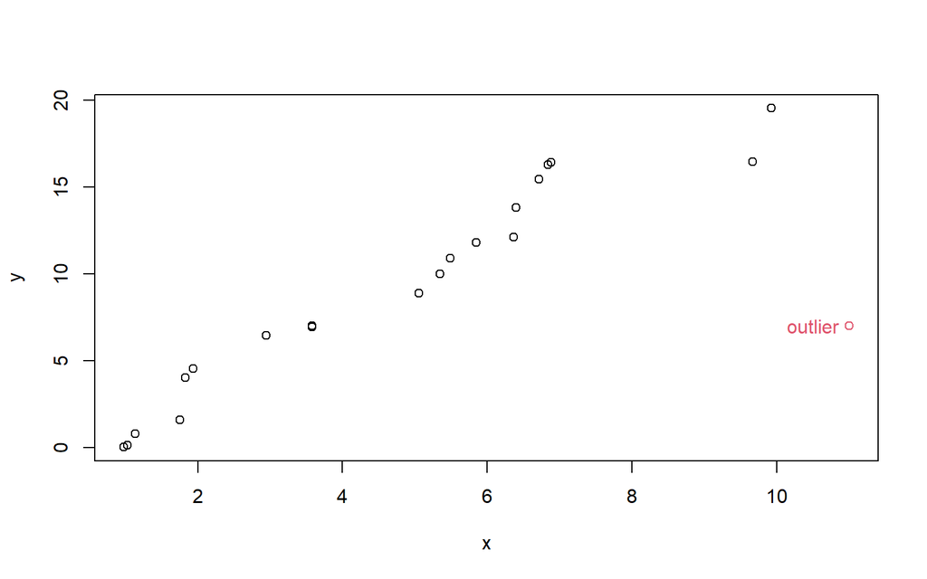

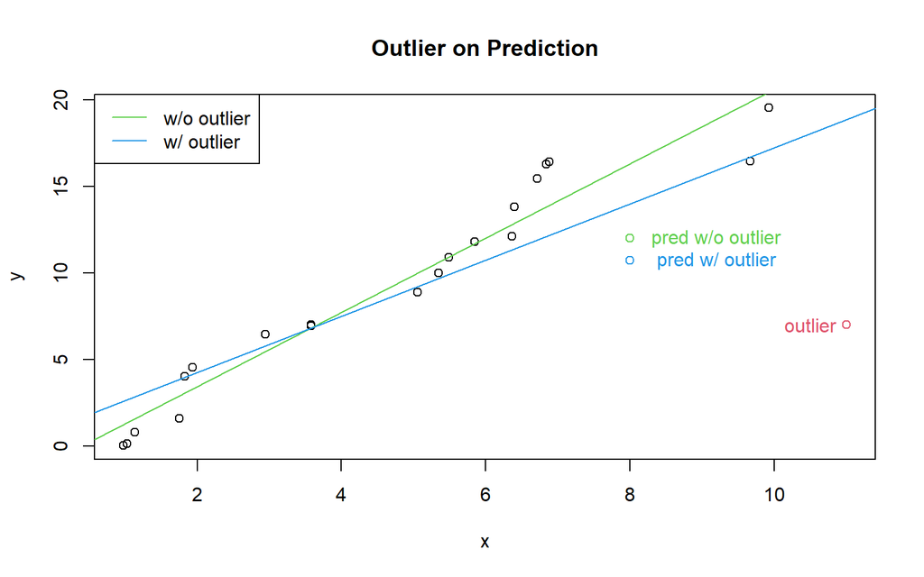

```r
newdata = data.frame(x = 6)

# regression w/o outlier
lm = lm(y ~ x, data)
y_pred = predict(lm, newdata)

# regression w/ outlier
lm1 = lm(y ~ x, data1)
y1_pred = predict(lm1, newdata)

# plot
plot(y ~ x, data1, col = rep(1:2, c(20, 1)), main = "Outlier on Prediction")
text(11-.5, 7, "outlier", col = 2)

abline(lm, col = 3)
abline(lm1, col = 4)
legend("topleft", legend = c("w/o outlier", "w/ outlier"), lty = 1, col = 3:4)

points(8, y_pred, col = 3)
text(8+1.2, y_pred, "pred w/o outlier", col = 3)
points(8, y1_pred, col = 4)
text(8+1.2, y1_pred, "pred w/ outlier", col = 4)
```

There is a bit of difference between the predicted value with and without outlier. If we regard the line from without outlier as closer to the population, then the prediction with outlier less likely. This is another reason we want to do something about outliers.

## 3. On classification

We can think of classification as discrete case of prediction. Then, the effect of outliers will be starker: classification into wrong categories. Especially, those near the boundaries of groups will influenced.

Let’s proceed with a three-group example.

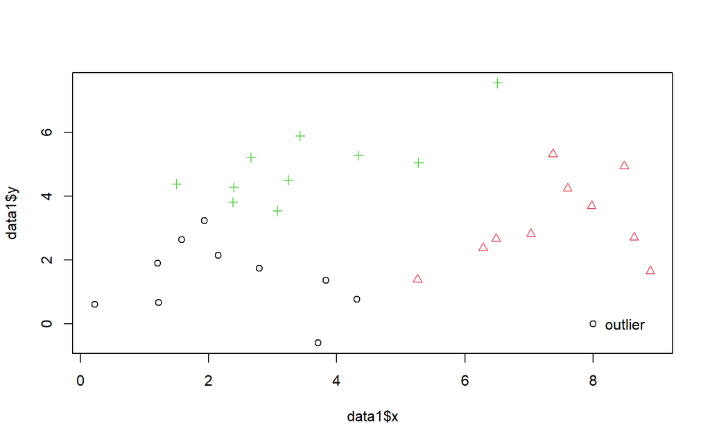

We have an unusual outlier from bottom-left group, located near right group. Let’s how this will do with an unsupervised k-Means clustering method.

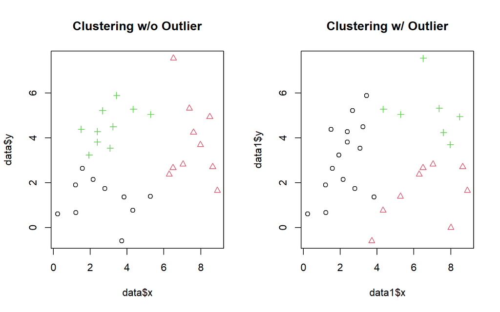

```r
par(mfrow = c(1, 2))
set.seed(99)

# w/o outlier
km = kmeans(data[, 1:2], 3)
pred = km$cluster
  pred[pred==1] = 5
  pred[pred==2] = 4
  pred[pred==3] = 6
  pred = pred-3
plot(data$x, data$y, col = pred, pch = pred, main = "Clustering w/o Outlier")

# w/ outlier
km1 = kmeans(data1[, 1:2], 3)
pred1 = km1$cluster
  pred1[pred1==1] = 4
  pred1[pred1==2] = 5
  pred1[pred1==3] = 6
  pred1 = pred1-3
plot(data1$x, data1$y, col = pred1, pch = pred1, main = "Clustering w/ Outlier")
```

We can definitely see the difference between the two results. The clustering accuracy without outlier is 0.9; while that with outlier is 0.5483871. A well-loated outlier can bring this big a difference.

These are easy examples with just few observations. In realistic data, there will be more observations - and more outliers, too. Then, the outliers will deviate the analysis results to wherever but the goal of such analysis.

# III. Detection

## 0. Dataset

For following detection methods, let’s use R’s built-in dataset *USArrests* as an example. *USArrests* consists of 50 observations and four variables: *Murder*, *Assault*, *UrbanPop* and *Rape*.

```r
data = USArrests
str(data)
```

```
## 'data.frame':    50 obs. of  4 variables:
##  $ Murder  : num  13.2 10 8.1 8.8 9 7.9 3.3 5.9 15.4 17.4 ...
##  $ Assault : int  236 263 294 190 276 204 110 238 335 211 ...
##  $ UrbanPop: int  58 48 80 50 91 78 77 72 80 60 ...
##  $ Rape    : num  21.2 44.5 31 19.5 40.6 38.7 11.1 15.8 31.9 25.8 ...
```

## 1. Eye Measures

No numerical criterion here. These rule-of-thumb methods mobilize common sense and background knowledge, and usually involve data visualization.

It doesn’t mean these methods are inferior, however. Numbers aren’t necessarily objective or more accurate; they are just good at drawing clear lines. Numbers cannot reflect insights and intuitions, which are often important in determining outliers and what to do about them. All methods are ultimately subjective.

### 1) Boxplot

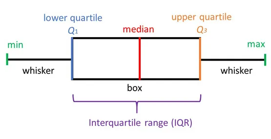

Boxplot is an explanatory chart, especially useful for a single variable, or multiple variables sharing units.

Boxplot uses five summary metrics: minimum, maximum, first and third quartile, and median. A box drawn from the first and the third quartiles, with median as a bar inside. From the box to minimum and maximum values, two whiskers are drawn.

From a boxplot, we can judge if a data is skewed or if there is any unusual observations(=outliers). Usually, boxplot is accompanied with IQR method to decide and mark outliers. I will explain this method in the next section.

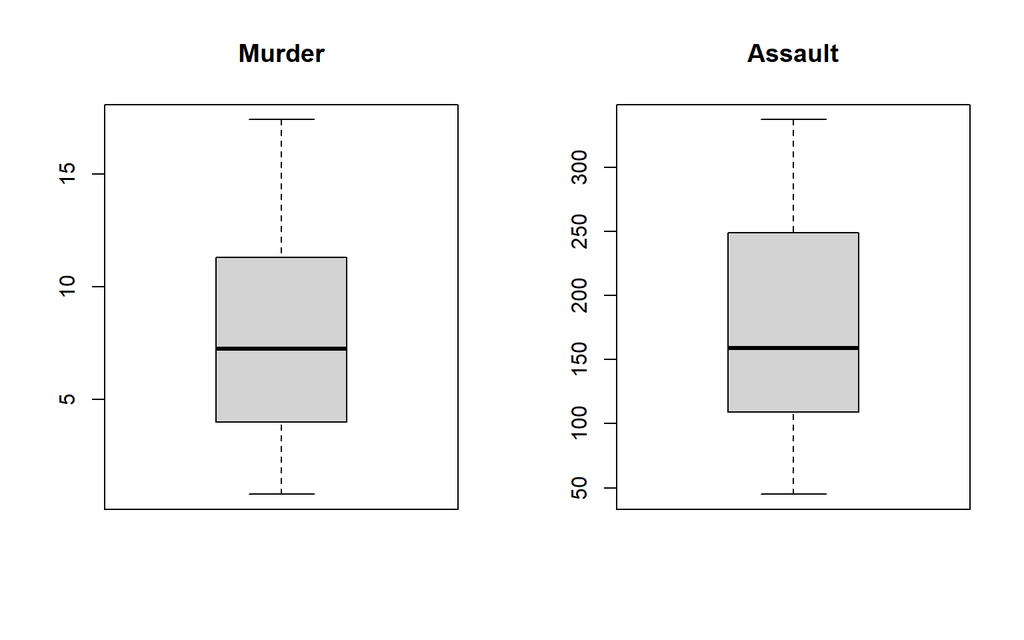

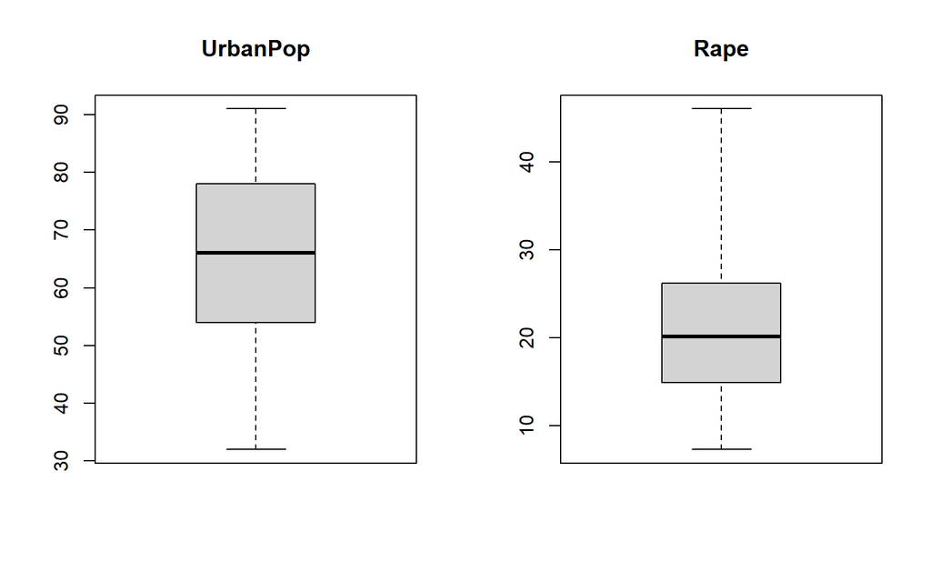

```r
par(mfrow = c(1, 2))
for (i in 1:4) {
  boxplot(data[, i], range = F)
  title(colnames(data)[i])
}
```

Above are boxplots drawn from *USArrests*’s variables. *Murder* and *Assault* are right skewed, but not by much. *UrbanPop* is slightly left skewed, but is more or less close symmetric. *Rape* is right skewed, and suggests the possibility of outliers somewhere at higher range.

### 2) Scatterplot

Scatterplot visualizes data on a two-dimension plane. It can be used to judge outliers with consideration of the relationship between two variables.

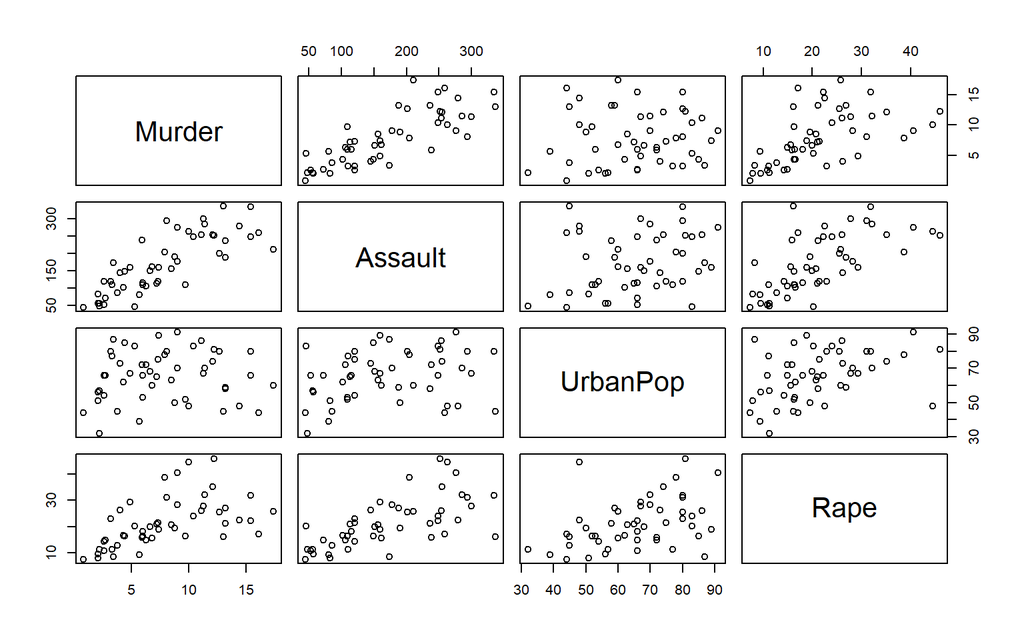

```r
plot(data)
```

*USArrests*’s four variables draw 6 scatterplot. The four variables seems to have positive correlations, although the strengths may vary. The stronger the correlation, the easier to find pattern, and therefore easier to spot outliers.

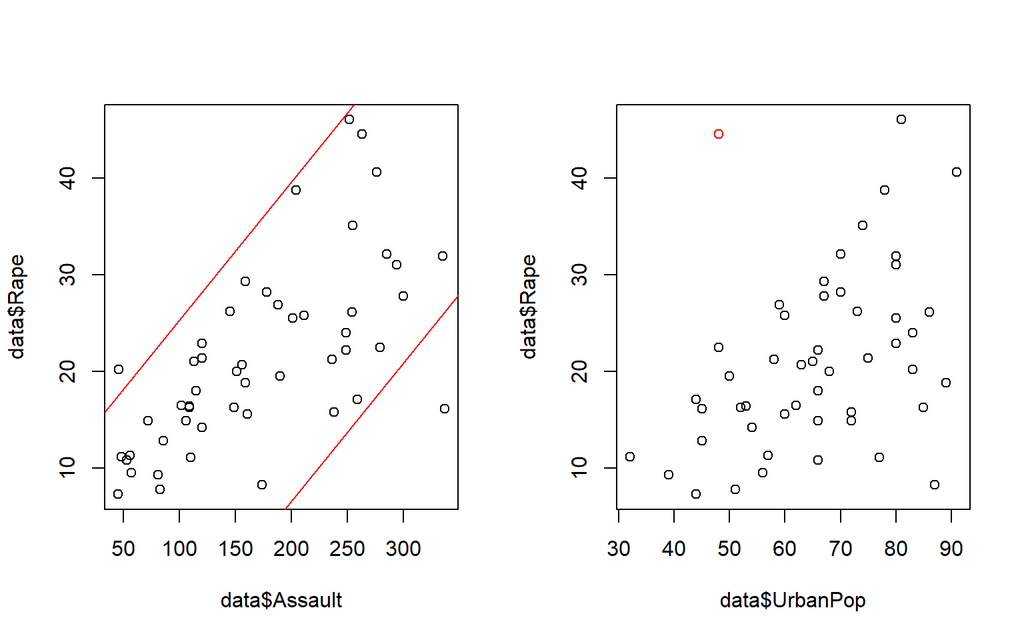

```r
par(mfrow = c(1,2))
plot(data$Assault, data$Rape)
abline(a = -22, b = 1/7, col = "red")
abline(a = 11, b = 1/7, col = "red")

plot(data$UrbanPop, data$Rape)
points(data["Alaska", 3:4], col = "red")
```

Let’s take farther look into *Assault*-*Rape* and *UrbanPop*-*Rape*. Between *Assault* and *Rape*, somewhat linear relation seems to exist. We can draw two arbitrary lines between which ordinary observations lie. The two points outside the region are possible outliers. Between *UrbanPop* and *Rape*, we can quite confidently point out an observation, marked in red. But for other observations, we can’t really tell anything for sure.

Of course, as 3-dimensional beings, we can try 3D scatterplot as well. Following is a 3d plot using *Assault*, *UrbanPop* and *Rape*. But it only makes life more difficult, rather than conveying more useful insights.

[interactive chart not shown]

### 3) Histogram

Histogram depicts the distribution of a data set based on frequencies. The layout of frequency bars gives a general sense of how a data set is distributed – whether it’s symmetric or skewed, whether it’s close to normal distribution or not, and so on. If we see any tiny bumps at either end of tails, we can label them as outliers.

As is true with other methods, histogram too can give varying results based on how one draw and interpret histograms. For example, setting each bin’s length small may allow you to spot outliers more easily.

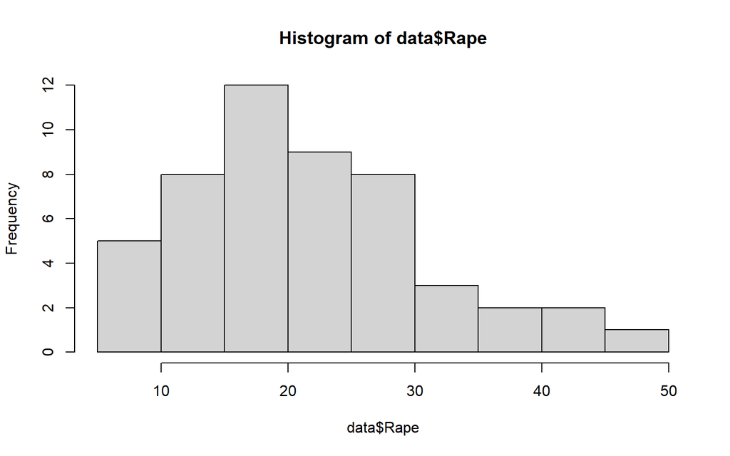

```r
hist(data$Rape, breaks = 10)
```

For example, *Rape* variable shows right-skewed distribution. We can either consider it as following such population distribution, or assume more symmetric distribution and regard the rightmost observations as outliers.

### 4) Distribution Plot

Distribution plot, too, depicts the general distribution of a given data. Difference is that distribution plot adds an assumption to smoothen the result, while histogram is free of any assumption as a nonparametric method. How much to smoothen is reflected in the assumption under the name of “bandwidth”. Higher the bandwidth, smoother the plot will be, but in cost of information loss.

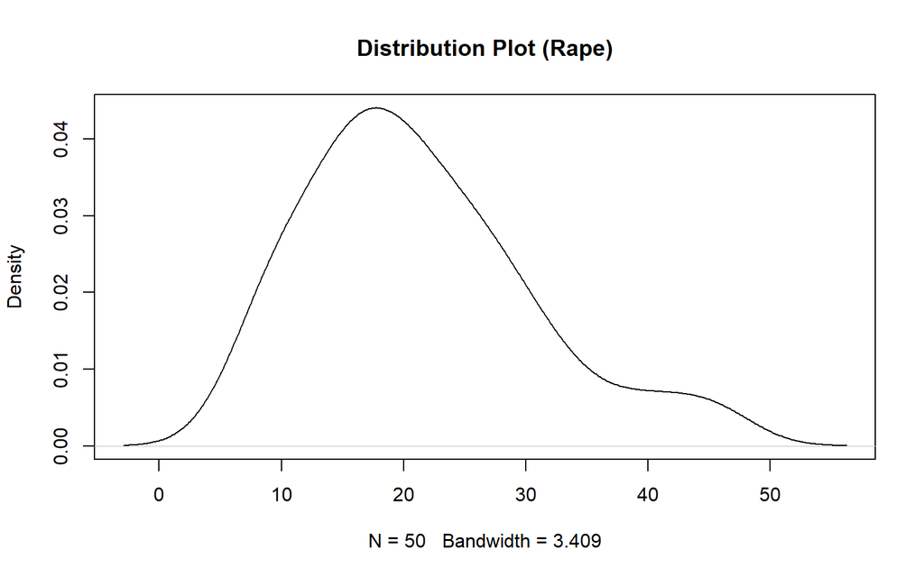

```r
plot(density(data$Rape), main = "Distribution Plot (Rape)")
```

### 5) QQ Plot

QQ plot (Quantile-Quantile plot) puts the quantiles of a data set against those of another data set. QQ plot is useful for comparing the distribution of two data sets. If two data sets follow similar distribution, the points will be aligned roughly on a straight line.
$$\text{QQ-plot}:~~~ ( F^{-1}(p), ~ G^{-1}(p) )$$

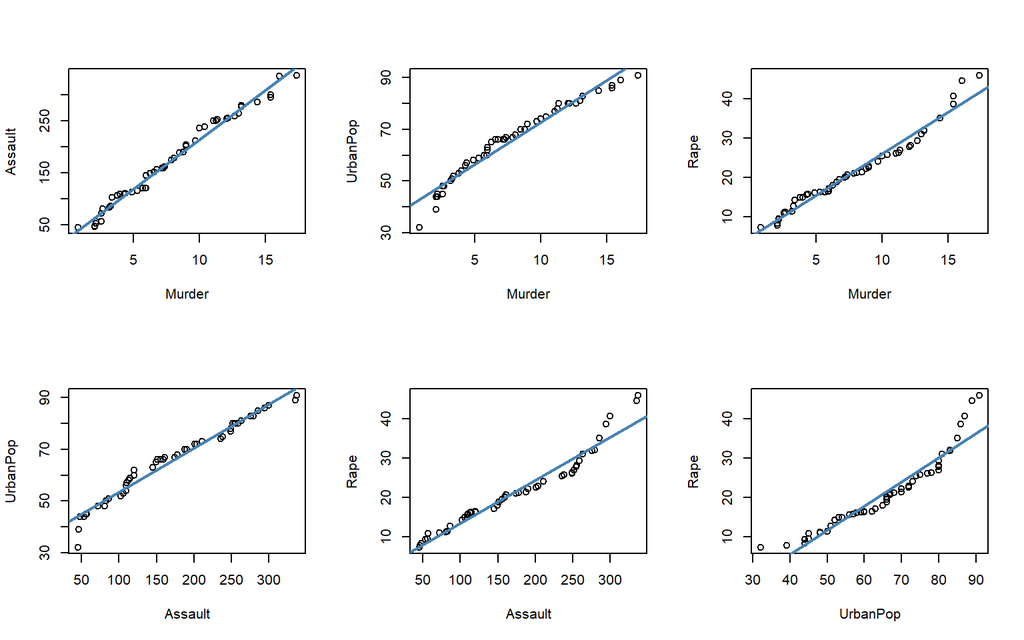

```r
par(mfrow = c(2, 3))
for (i in 1:3) {
  for (j in (i+1):4) {
    qp = qqplot(data[, i], data[, j], xlab = colnames(data)[i], ylab = colnames(data)[j])
    abline(lm(qp$y ~ qp$x), col = "steelblue", lwd = 2)
  }
}
```

Another use is to compare a data set to a normal distribution.

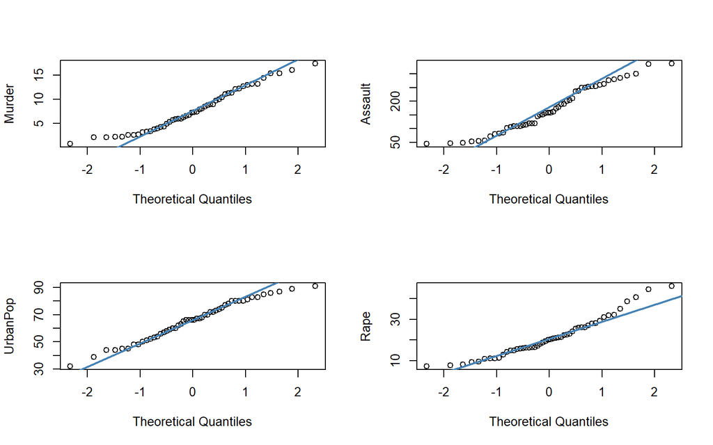

```r
par(mfrow = c(2, 2))
for (i in 1:4) {
  qqnorm(data[, i], ylab = colnames(data)[i], main = "")
  qqline(data[, i], col = "steelblue", lwd = 2)
}
```

Points straying away from the straight line indicates deviation from normal distribution. That a data set distributed different from normal distribution does not necessarily mean it has outliers. Yet, we can spot any observation that stands out from a data set’s own pattern to be an outlier.

## 2. Numerical Criterions

### 1) IQR Method

One of the most common and easiest method of numerically deciding outliers is through IQR(Inter-Quartile Range). IQR is defined as following:
$$IQR = Q_3 - Q_1$$
Then, an outlier is defined based on the distance from the median in terms of IQR:
$$Outlier = \{ x | x > Q_3 + 1.5 \times IQR \} \cup \{ x | x < Q_1 - 1.5 \times IQR \}$$

Here, the two boundaries are called **upper fence** and **lower fence**. Maximum and minimum are designated again from the observations within the fences, and any observations outside are decided as outliers.

Fences can be farther splitted into **inner fence** and **outer fence**.
$$\begin{align}
Inner Fence &: Q_1 - 1.5 \times IQR, ~ Q_3 + 1.5 \times IQR \\
Outer Fence &: Q_1 - 3 \times IQR, ~ Q_3 + 3 \times IQR
\end{align}$$

Those between inner and outer fences are called **mild outliers**, while those outside outer fences are called **extreme outliers**.

### 2) Z-score Method

Z-score is a standardized value for an observation. Assuming normal distribution for a small sample, or without doing so for a large sample(CLT), Z-score follows standard normal distribution.
$$Z = {X - \mu \over \sigma}$$

Z-score method utilizes the three-sigma rule of thumb to set the bar: any observation that has absolute Z-score larger than 3 is considered an outlier (which gives this method another name of “sigma clipping”).
$$\text{Z-score criterion}: |Z|>3$$

This rule comes from that about 99.7% of data lie within three-sigma boundary($\mu \pm 3\sigma$). If normal assumption or CLT holds, we can reasonably say an observation with likelihood of less than 0.3% is an outlier.

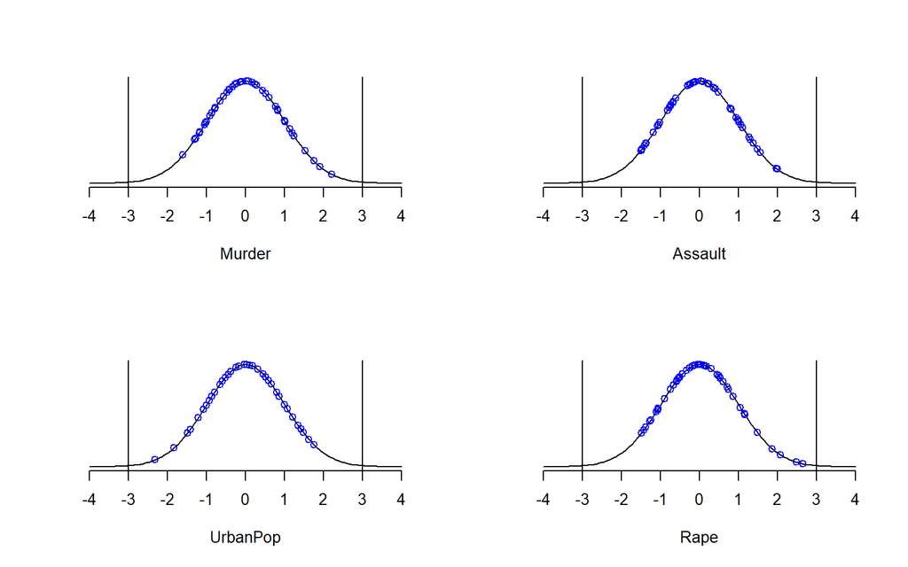

```r
data_z = scale(data) # standardization

# points for normal dist plot
x = seq(-4, 4, length = 100)
y = dnorm(x)

par(mfrow = c(2, 2))
for (i in 1:4) {
  plot(x, y, type = "l", lwd = 1, axes = F, xlab = colnames(data)[i], ylab = "")
  axis(1, at = -4 : 4)
  abline(v = c(-3, 3))
  points(data_z[, i], dnorm(data_z[, i]), col = "blue")
}
```

In case of *USArrests* data set, no outlier is detected from Z-score method.

### 3) Modified Z-score

Modified Z-score, or Robust Z-score, is similar to the previous method, with some difference in parameters. One downside of using plain Z-score method is that mean and standard deviations (both mean-based parameters) are prone to sensitive to outliers. To mitigate this issue, the Robust Z-score method utilizes Median and MAD in place of mean and standard deviations. This is why the method is also called **Median Absolute Deviation method**.
$$M_i = { 0.6745 (X_i - Median) \over MAD}$$
where $MAD = median(|X_i - median(X)|)$. The constant 0.6745 is needed to retain unbiasedness, for $E(MAD)=0.6745\sigma$ for large $n$.

The new criterion is as follows:
$$\text{R.Z. score criterion}: |M_i| > 3.5$$
Here, 3.5 is suggested by Iglewicz and Hoaglin.[^1] Any observation lying within the area are labeled as potential outliers.

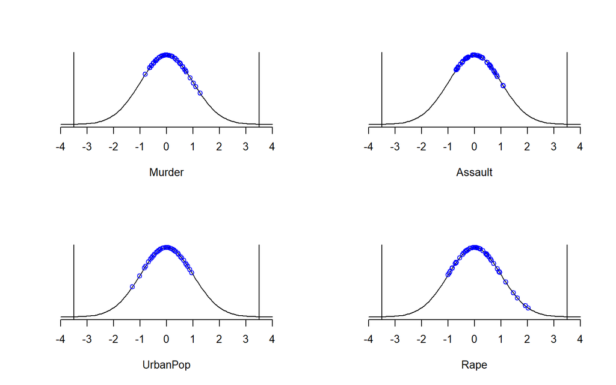

```r
# points for normal dist plot
x = seq(-4, 4, length = 100)
y = dnorm(x)

par(mfrow = c(2, 2))
for (i in 1:4) {
  #
  xi = data[, i]
  median = median(xi)
  mad = mad(xi)
  mi = 0.6745 * (xi - median) / mad

  plot(x, y, type = "l", lwd = 1, axes = F, xlab = colnames(data)[i], ylab = "")
  axis(1, at = -4 : 4)
  abline(v = c(-3.5, 3.5))
  points(mi, dnorm(mi), col = "blue")
}
```

In terms of modified Z-score method, neither any of *USArrests* variables have outliers.

### 4) Winsorization Method

Winsorization simply cuts of certain percentage of data from both ends, and replace them with the corresponding percentiles. That is, outlier is labeled solely based on percentile. For example, any observation greater than 95th percentile will be replaced to the value of 95th percentile.

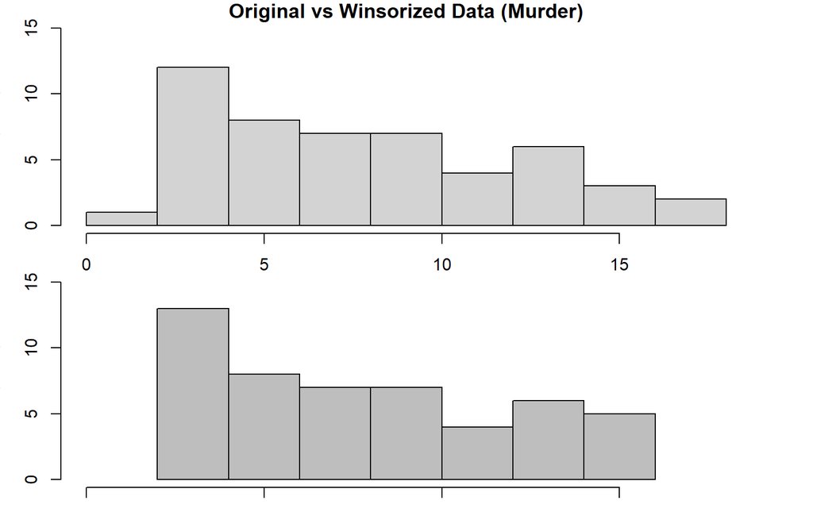

```r
# indexes for whether extreme
index_upper = data$Murder > quantile(data$Murder, .95)
index_lower = data$Murder < quantile(data$Murder, .05)

# replace
winsorized = data$Murder
winsorized[index_upper] = quantile(data$Murder, .95)
winsorized[index_lower] = quantile(data$Murder, .05)

# comparison
par(mfrow = c(2, 1), mar = c(1, 3, 1, 3))
hist(data$Murder, main = "Original vs Winsorized Data (Murder)",
     xlim = c(0, 18), ylim = c(0, 15), xlab = "")
hist(winsorized, col = "gray", main = "",
     xlim = c(0, 18), ylim = c(0, 15), xlab = "")
```

## 3. Statistical Tests

Statistics can’t go without distributions and tests. Taking one step further from just numerical criterion, statisticians invented statistical tests for eliminating outliers. Such tests rely on probabilistic functions, rather than suggesting arbitrary rule of thumbs.

### 1) Chauvenet’s Criterion

#### (1) Rule

> If the expected number of measurements at least as bad as the suspect measurement is less than 1/2, then the suspect measurement should be rejected. [^2]

#### (2) erf and erfc

Chauvenet’s criterion uses a function named *erfc*, which stands for the complmentary error function. erfc is related to *erf*, the error funcion. Two functions are defined as follows:
$$\begin{align}
erf~x &= {2 \over \sqrt{\pi}} \int^x_0 {e^{-t^2}} dt \\
erfc~x &= 1 - erf~x = {2 \over \sqrt{\pi}} \int^\infty_x {e^{-t^2}} dt
\end{align}$$

The error function and the complementary error function are derived from the standard normal CDF. These two functions are essentially equivalent; specifically, erfc represents the area under the two tails of zero mean Gaussian probability density function of variance $\sigma^2 = 1/2$. [^3]

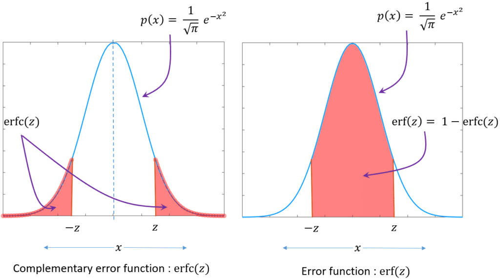

#### (3) Procedure

1. Calculate $\mu$ and $\sigma$
2. If $n \times erfc( {|x_i - \mu| \over \sigma} ) < 1/2$, then reject $x_i$.
3. Repeat step 1 and 2 until step 2 passes or too many points are rejected.[^4]
4. Report final $\mu$, $\sigma$, and $n$

Of course, we have to use sample statistics in place of parameters. Also, we can see that the normal assumption is introduced.

#### (4) Intuition

$erfc( {|x_i - \mu| \over \sigma} )$ represents the possibility of there being more extreme observation than the observation of interest, based on the distance from the mean. Multiply that by the sample size, $n \times erfc( {|x_i - \mu| \over \sigma} )$ represents the expected amount of more extreme observations. If this does not round up to 1 (hence the magic number $1/2$), such observation is not likely and thus can be rejected as an outlier.

Where Chauvenet’s magic number is 1/2, other numbers are also possible. For example, 1/3 is more generous standard, while 3/5 more strict.

Another property is that the sample size $n$ serves important role here. The bigger the sample size, less likely an observation will be rejected, for the left side of the inequation gets bigger. The intuition is that for a bigger sample, more likely there will be larger or smaller observations, and thus a potential outlier may not actually be that *outlying*.

#### (5) Using critical values

Since Chauvenet’s criterion utilizes normal distribution, we can use prebuilt table of critical values to decide whether to reject an outlier or not, as we do with general statistical tests.

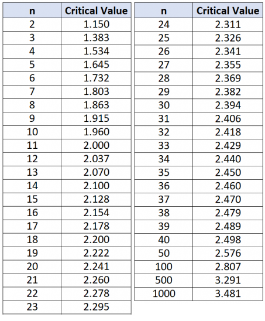

For a given $n$, if the Z-score for an observation exceeds the critical value (${x_i - \bar{x} \over s} > c$), we can declare that observation as an outlier.

#### (6) Example

```r
n = length(data$Rape)
xbar = mean(data$Rape)
s = sd(data$Rape)

index = c()
for (i in 1:n) {
  z = abs(data$Rape[i] - xbar) / s
  int = integrate(function(x){exp(-x^2)}, 0, z)
  erfc = 1 - (2/sqrt(pi) * int$value)
  t = n * erfc
  index[i] = t < 1/2
}
```

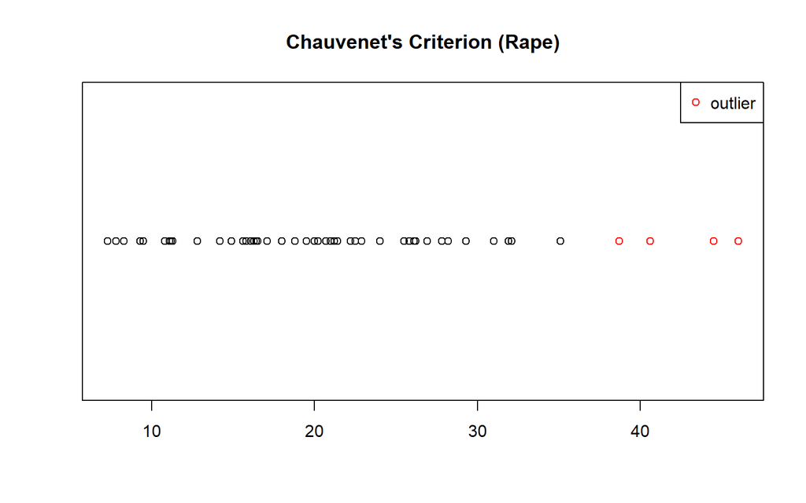

```r
stripchart(data$Rape, col = !index, pch = 1)
title("Chauvenet's Criterion (Rape)")
stripchart(data$Rape[index], col = "red", pch = 1, add = TRUE)
legend("topright", legend = "outlier", col = "red", pch = 1)
```

Chauvenet’s criterion detects 4 outliers from *Rape* variable.

### 2) Peirce’s Criterion

#### (1) Rule

> …the proposed observations should be rejected when the probability of the system of errors obtained by retaining them is less than that of the system of errors obtained by their rejection multiplied by the probability of making so many, and no more, abnormal observation. [^5]

#### (2) Statistics

$$R = { |x_i - \mu|_{max} \over \sigma}$$

#### (3) Procedure

1. Calculate $\mu$ and $\sigma$
2. Obtain R from Peirce’s table corresponding to the sample size. Assume *one* doubtful observation at first.
3. Calculate the maximum allowable deviation: $|x_i - \mu|_{max}$
4. Calculate $|x_i - \mu|$ for a suspicious observation
5. Compare the results from step 3 and 4. Eliminate the observation if:
   $$|x_i - \mu| > |x_i - \mu|_{max}$$
6. If an observation is eliminated in step 5, assume now *two* suspicious observations and redo step 2 ~ 5. Keep the original $\mu$, $\sigma$ and $n$.
7. If more than one observation is eliminated, assume the next highest number of suspicious observations and redo step 2 ~ 5. Repeat until no more elimination is needed.
8. Report the new $\mu$, $\sigma$ and $n$.

#### (4) Peirce’s Criterion Table [^6]

Peirce Criterion Table

| n | # of doubtful observations 1 | # of doubtful observations 2 | # of doubtful observations 3 | # of doubtful observations 4 | # of doubtful observations 5 | # of doubtful observations 6 | # of doubtful observations 7 | # of doubtful observations 8 | # of doubtful observations 9 |
| --- | --- | --- | --- | --- | --- | --- | --- | --- | --- |
| 3 | 1.196 |  |  |  |  |  |  |  |  |
| 4 | 1.383 | 1.078 |  |  |  |  |  |  |  |
| 5 | 1.509 | 1.200 |  |  |  |  |  |  |  |
| 6 | 1.610 | 1.299 | 1.099 |  |  |  |  |  |  |
| 7 | 1.693 | 1.382 | 1.187 | 1.022 |  |  |  |  |  |
| 8 | 1.763 | 1.453 | 1.261 | 1.109 |  |  |  |  |  |
| 9 | 1.824 | 1.515 | 1.324 | 1.178 | 1.045 |  |  |  |  |
| 10 | 1.878 | 1.570 | 1.380 | 1.237 | 1.114 |  |  |  |  |
| 11 | 1.925 | 1.619 | 1.430 | 1.289 | 1.172 | 1.059 |  |  |  |
| 12 | 1.969 | 1.663 | 1.475 | 1.336 | 1.221 | 1.118 | 1.009 |  |  |
| 13 | 2.007 | 1.704 | 1.516 | 1.379 | 1.266 | 1.167 | 1.070 |  |  |
| 14 | 2.043 | 1.741 | 1.554 | 1.417 | 1.307 | 1.210 | 1.120 | 1.026 |  |
| 15 | 2.076 | 1.775 | 1.589 | 1.453 | 1.344 | 1.249 | 1.164 | 1.078 |  |
| 16 | 2.106 | 1.807 | 1.622 | 1.486 | 1.378 | 1.285 | 1.202 | 1.122 | 1.039 |
| 17 | 2.134 | 1.836 | 1.652 | 1.517 | 1.409 | 1.318 | 1.237 | 1.161 | 1.084 |
| 18 | 2.161 | 1.864 | 1.680 | 1.546 | 1.438 | 1.348 | 1.268 | 1.195 | 1.123 |
| 19 | 2.185 | 1.890 | 1.707 | 1.573 | 1.466 | 1.377 | 1.298 | 1.226 | 1.158 |
| 20 | 2.209 | 1.914 | 1.732 | 1.599 | 1.492 | 1.404 | 1.326 | 1.255 | 1.190 |
| 21 | 2.230 | 1.938 | 1.756 | 1.623 | 1.517 | 1.429 | 1.352 | 1.282 | 1.218 |
| 22 | 2.251 | 1.960 | 1.779 | 1.646 | 1.540 | 1.452 | 1.376 | 1.308 | 1.245 |
| 23 | 2.271 | 1.981 | 1.800 | 1.668 | 1.563 | 1.475 | 1.399 | 1.332 | 1.270 |
| 24 | 2.290 | 2.000 | 1.821 | 1.689 | 1.584 | 1.497 | 1.421 | 1.354 | 1.293 |
| 25 | 2.307 | 2.019 | 1.840 | 1.709 | 1.604 | 1.517 | 1.442 | 1.375 | 1.315 |
| 26 | 2.324 | 2.037 | 1.859 | 1.728 | 1.624 | 1.537 | 1.462 | 1.396 | 1.336 |
| 27 | 2.341 | 2.055 | 1.877 | 1.746 | 1.642 | 1.556 | 1.481 | 1.415 | 1.356 |
| 28 | 2.356 | 2.071 | 1.894 | 1.764 | 1.660 | 1.574 | 1.500 | 1.434 | 1.375 |
| 29 | 2.371 | 2.088 | 1.911 | 1.781 | 1.677 | 1.591 | 1.517 | 1.452 | 1.393 |
| 30 | 2.385 | 2.103 | 1.927 | 1.797 | 1.694 | 1.608 | 1.534 | 1.469 | 1.411 |
| 31 | 2.399 | 2.118 | 1.942 | 1.812 | 1.710 | 1.624 | 1.550 | 1.486 | 1.428 |
| 32 | 2.412 | 2.132 | 1.957 | 1.828 | 1.725 | 1.640 | 1.567 | 1.502 | 1.444 |
| 33 | 2.425 | 2.146 | 1.971 | 1.842 | 1.740 | 1.655 | 1.582 | 1.517 | 1.459 |
| 34 | 2.438 | 2.159 | 1.985 | 1.856 | 1.754 | 1.669 | 1.597 | 1.532 | 1.475 |
| 35 | 2.450 | 2.172 | 1.998 | 1.870 | 1.768 | 1.683 | 1.611 | 1.547 | 1.489 |
| 36 | 2.461 | 2.184 | 2.011 | 1.883 | 1.782 | 1.697 | 1.624 | 1.561 | 1.504 |
| 37 | 2.472 | 2.196 | 2.024 | 1.896 | 1.795 | 1.711 | 1.638 | 1.574 | 1.517 |
| 38 | 2.483 | 2.208 | 2.036 | 1.909 | 1.807 | 1.723 | 1.651 | 1.587 | 1.531 |
| 39 | 2.494 | 2.219 | 2.047 | 1.921 | 1.820 | 1.736 | 1.664 | 1.600 | 1.544 |
| 40 | 2.504 | 2.230 | 2.059 | 1.932 | 1.832 | 1.748 | 1.676 | 1.613 | 1.556 |
| 41 | 2.514 | 2.241 | 2.070 | 1.944 | 1.843 | 1.760 | 1.688 | 1.625 | 1.568 |
| 42 | 2.524 | 2.251 | 2.081 | 1.955 | 1.855 | 1.771 | 1.699 | 1.636 | 1.580 |
| 43 | 2.533 | 2.261 | 2.092 | 1.966 | 1.866 | 1.783 | 1.711 | 1.648 | 1.592 |
| 44 | 2.542 | 2.271 | 2.102 | 1.976 | 1.876 | 1.794 | 1.722 | 1.659 | 1.603 |
| 45 | 2.551 | 2.281 | 2.112 | 1.987 | 1.887 | 1.804 | 1.733 | 1.670 | 1.614 |
| 46 | 2.560 | 2.290 | 2.122 | 1.997 | 1.897 | 1.815 | 1.743 | 1.681 | 1.625 |
| 47 | 2.568 | 2.299 | 2.131 | 2.006 | 1.907 | 1.825 | 1.754 | 1.691 | 1.636 |
| 48 | 2.577 | 2.308 | 2.140 | 2.016 | 1.917 | 1.835 | 1.764 | 1.701 | 1.646 |
| 49 | 2.585 | 2.317 | 2.149 | 2.026 | 1.927 | 1.844 | 1.773 | 1.711 | 1.656 |
| 50 | 2.592 | 2.326 | 2.158 | 2.035 | 1.936 | 1.854 | 1.783 | 1.721 | 1.666 |
| 51 | 2.600 | 2.334 | 2.167 | 2.044 | 1.945 | 1.863 | 1.792 | 1.730 | 1.675 |
| 52 | 2.608 | 2.342 | 2.175 | 2.052 | 1.954 | 1.872 | 1.802 | 1.740 | 1.685 |
| 53 | 2.615 | 2.350 | 2.184 | 2.061 | 1.963 | 1.881 | 1.811 | 1.749 | 1.694 |
| 54 | 2.622 | 2.358 | 2.192 | 2.069 | 1.972 | 1.890 | 1.820 | 1.758 | 1.703 |
| 55 | 2.629 | 2.365 | 2.200 | 2.077 | 1.980 | 1.898 | 1.828 | 1.767 | 1.711 |
| 56 | 2.636 | 2.373 | 2.207 | 2.085 | 1.988 | 1.907 | 1.837 | 1.775 | 1.720 |
| 57 | 2.643 | 2.380 | 2.215 | 2.093 | 1.996 | 1.915 | 1.845 | 1.784 | 1.729 |
| 58 | 2.650 | 2.387 | 2.223 | 2.101 | 2.004 | 1.923 | 1.853 | 1.792 | 1.737 |
| 59 | 2.656 | 2.394 | 2.230 | 2.109 | 2.012 | 1.931 | 1.861 | 1.800 | 1.745 |
| 60 | 2.663 | 2.401 | 2.237 | 2.116 | 2.019 | 1.939 | 1.869 | 1.808 | 1.753 |

#### (5) Example

Let’s try the sample example data of from Chauvenet’s criterion. The value of R for $n=50$ and one suspicious observation is $R=2.5922$. From this, we can obtain $|x_i - \mu|_{max} = R \times \sigma = 24.280$. Comparing the maximum allowed deviation and actual deviations, we get one outlier, 46.

```r
xbar = mean(data$Rape)
s = sd(data$Rape)

R1 = 2.592
maxallowed1 = R1 * s
deviation = abs(data$Rape - xbar)
data$Rape[deviation > maxallowed1]
```

```
## [1] 46
```

Now let’s assume two suspicious observations. $R=2.326$ for this case.

```r
R2 = 2.326
maxallowed2 = R2 * s
data$Rape[deviation > maxallowed2]
```

```
## [1] 44.5 46.0
```

…and we get two outliers.

```r
R3 = 2.158
maxallowed3 = R3 * s
data$Rape[deviation > maxallowed3]
```

```
## [1] 44.5 46.0
```

But for three suspicious observations, we do not get any further outliers. We can conclude there are two outliers, 44.5 and 46.0.

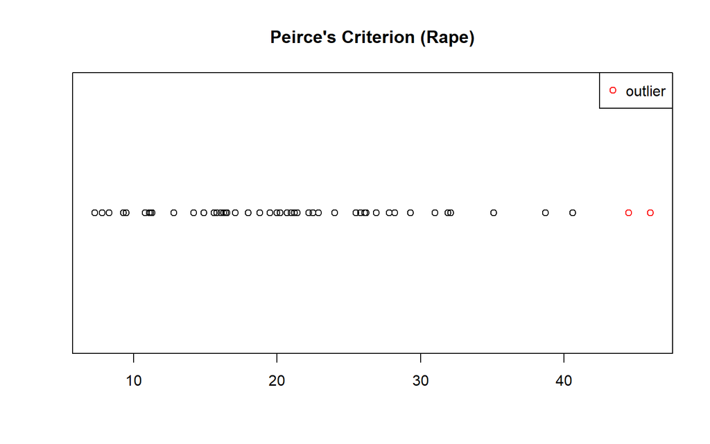

```r
index = deviation > maxallowed2

stripchart(data$Rape, col = !index, pch = 1)
title("Peirce's Criterion (Rape)")
stripchart(data$Rape[index], col = "red", pch = 1, add = TRUE)
legend("topright", legend = "outlier", col = "red", pch = 1)
```

#### (6) Peirce vs Chauvenet

- Although Chauvenet’s criterion is more commonly used, it makes arbitrary assumptions regarding the rejection of the data; while Peirce’s criterion does not.
- Two criteria also differ in that Peirce’s criterion can be applied in case of several suspicious data values, while Chauvenet’s does not distinguish between a single and multiple cases.

### 3) Modified Thompson Tau Test

#### (1) Approach

The modified Thompson Tau test is used to decide whether a suspected observation from a univariate data set is an outlier.

#### (2) Test statistic

$$T = {\delta \over s} = {\max|x_i - \mu| \over s}$$
$\delta$ indicates the maxmimum absolute difference.

#### (3) Critical region

$$\tau = {(n-1) t_{\alpha/2, n-2} \over \sqrt{n} \sqrt{n-2+t^2_{\alpha/2, n-2}}}$$
Reject the null hypothesis if:
$$T= {\delta \over s} > \tau \qquad \text{or} \qquad \delta > \tau \cdot s$$

#### (4) Tau table [^7]

Or, we can use pre-calculated tau values.

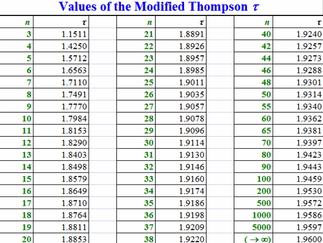

#### (5) Example

```r
xbar = mean(data$Rape)
s = sd(data$Rape)
n = length(data$Rape)
a = 0.05

# test statistics
delta = abs(max(data$Rape - xbar))

# critical value
t = qt(p = a/2, df = n-2, lower.tail = FALSE)
tau = (n-1) * t / (sqrt(n) * sqrt(n-2+t^2))

# hypothesis test
paste("delta=", delta, " > ", round(tau*s, 4), "=tau*s ? : ", delta > tau*s, sep = "")
```

```
## [1] "delta=24.768 > 18.0899=tau*s ? : TRUE"
```

According to the modified Thompson’s tau test, under 5% significance level, we have enough statistical evidence to conclude that the maximum value 46 is an outlier.

### 4) Grubbs’ Test

#### (1) Idea and assumption

Grubbs’ test is used for detecting a *single* outlier in a univariate data set that follows *approximately normal* distribution.

#### (2) Hypothesis

H<sub>0</sub>: There are no outliers in the data set H<sub>1</sub>: There is exactly one outlier in the data set

#### (3) Test statistic

$$G = {\max |x_i - \bar{x}| \over s}$$
The Grubb’s test statistic is the largest absolute deviation from the sample mean in units of the sample standard deviation.[^8] For two-sided test, we try to see if the test statistic is large enough.

For one sided test, test statistics will be either $G={x_{max} - \bar{x} \over s}$ or $G={\bar{x} - x_{min} \over s}$.

#### (4) Critical region

Reject the null hypothesis if:
$$G > {n-1 \over \sqrt{n}} \sqrt{(t_{\alpha/2n, n-2})^2 \over {n-2+(t_{\alpha/2n, n-2})^2}}$$
That is, the maximum or the minimum value (the absolute value of whichever is larger) is marked as an outlier if $G$ is large enough. For one-sided tests, significance level will be $\alpha/n$ instead of $\alpha/2n$.

We can again see that the sample size $n$ serves certain role here. As $n$ gets larger, 1) $n-1 \over \sqrt{n}\sqrt{n-2...}$ too gets bigger, and 2) $\sqrt{t^2 \over ...+t^2}$ gets bigger. It means that as $n$ grows, the right side of the inequation grows, and it gets harder to reject the null hypothesis.

#### (5) Example

```r
G = max(abs(data$Rape - xbar)) / s
n = length(data$Rape)

a = 0.05
t = qt(p = a/2/n, df = n-2, lower.tail = F)
C = (n-1/sqrt(n)) * sqrt(t^2 / (n-2+t^2))
paste("G=", round(G, 4), " > ", round(C, 4), "=C ? : ", G>C, sep = "")
```

```
## [1] "G=2.6444 > 22.5076=C ? : FALSE"
```

Following Grubbs’ test, under 5% significance level, we do not have enough statistical evidence to say that there exists an outlier.

### 5) Tietjen-Moore Test

#### (1) Idea and assumption

Tietjen-Moore test can be thought as an extension of Grubbs’ test – it can be used to detect *multiple* outliers in a univariate data set that follows *approximately normal* distribution. Here, the number of outliers – $k$ – has to be prespecified.

#### (2) Hypothesis

H<sub>0</sub>: There are no outliers in the data set H<sub>1</sub>: There are exactly k outliers in the data set

#### (3) Test statistics

Let $x_{(i)}$ denote the $i$th largest data value, and $\bar{x}$ the sample mean for the full sample.

- The test statistics for the $k$ largest points is:
  $$L_k = {\sum^{n-k}_{i=1}(x_{(i)}-\bar{x_k})^2 \over \sum^n_{i=1}(x_{(i)}-\bar{x})^2}$$
  where $\bar{x_k}$ indicates the sample mean without the largest $k$ points.
- The test statistics for the $k$ smallest points is:
  $$L_k = {\sum^{n}_{i=k+1}(x_{(i)}-\bar{x_k})^2 \over \sum^n_{i=1}(x_{(i)}-\bar{x})^2}$$
  where $\bar{x_k}$ indicates the sample mean without the smallest $k$ points.
- For two-sided tests, let $r_i=|x_i - \bar{x}|$ and $r_{(i)}$ be the $i$th largest value from $r_i$’s. The test statistics is then:
  $$E_k = {\sum^{n}_{i=k+1}(r_{(i)}-\bar{r_k})^2 \over \sum^n_{i=1}(r_{(i)}-\bar{r})^2}$$
  where $\bar{r_k}$ indicates the sample mean without the largest $k$ points.

#### (4) Critical region

The critical value of Tietjen-Moore test is obtained through Monte Carlo *simulations* rather than chosen from a distribution. Specifically, a standard normal random sample of size $n$ is generated, say, 10,000 times to compute the test statistics. Then, from the approximated distribution of $L_k$ or $E_k$, the critical value is obtained. [^9]

The test statistics have values between 0 to 1. If the potentially extreme values have distances from the mean big enough, the difference between nominator and denominator will be big, resulting in smaller test statistics. If the test statistics is small enough, the null hypothesis will be rejected. That is, Tietjen-Moore test is always left-tailed test.

#### (5) Example

Suppose we are suspecting $k=2$ outliers to the right tail. We have to simulate the distribution of $L_k$.

```r
set.seed(99)
n = length(data$Rape)
nIter = 10000
k = 2

# simulation
Lk = c()
for (i in 1:nIter) {
  sim = sort(rnorm(n), decreasing = F)
  sim_wo_k = sim[1:(n-k)]
  Lk[i] = (var(sim_wo_k)*(n-k-1)) / (var(sim)*(n-1))
}

# critical value for alpha=0.05
C = quantile(Lk, 0.05)

# test statistics
sample = sort(data$Rape, decreasing = F)
sample_wo_k = sample[1:(n-k)]
t = (var(sample_wo_k)*(n-k-1)) / (var(sample)*(n-1))

# hypothesis test
paste("L_k=", round(t, 5), " < C=", round(C, 5), " ? : ", t<C, sep = "")
```

```
## [1] "L_k=0.72017 < C=0.72002 ? : FALSE"
```

Since $L_k=0.7202 > 0.7200=C$, under 5% sigfinicance level, we cannot reject the null hypothesis. That is, we do not have enough statistical evidence to conclude that *Rape* data has exactly 2 outliers. (Yet the difference being only slightly, different result may be possible depending on which seed is used.)

### 6) Generalized ESD Test

#### (1) Idea and assumptions

The generalized **E**xtreme **S**tudentized **Deviate** test is used for detecting *one or more* outliers in a univariate data set that follows an *approximately normal* distribution. This test is essentially the Grubbs’ test applied sequentially. For a prespeficied upper bound $r$, $r$ separate tests for each number of outliers are performed. [^10]

#### (2) Hypothesis

H<sub>0</sub>: There are no outliers in the data set H<sub>1</sub>: There are up to r outliers in the data set

#### (3) Test statistics

$$R_i = {\max _i |x_i - \bar{x}| \over s}$$

$R_i$ is computed for each $i$th outlier. That is, $R_1$ is computed with the whole data; then an outlier is removed, and $R_2$ is calculated with $n-1$ observations; then another outlier is removed and $R_3$ is computed, and so on until $r$th outlier is removed. As a result, $r$ test statistics $R_1$, $R_2$, …, $R_r$ will be obtained.

#### (4) Critical Region

$$\lambda _i = {(n-i)t_{p, n-i-1} \over \sqrt{(n-i-1+t_{p, n-i-1}^2)(n-i+1)}}, \quad i=1, 2, 3, ...,r$$
where $p = 1 - {\alpha \over 2(n-i+1)}$.

The number of outliers is determined by finding the largest $i$ such that $R_i > \lambda _i$.

#### (5) Example

Let’s proceed with $r=5$.

```r
x = data$Rape
n = length(data$Rape)
a = 0.05

Ri = c()
C = c()
res = c()
for (i in 1:5) {
  xbar = mean(x)
  s = sd(x)

  # test statistic
  Ri[i] = max(abs(x - xbar)) / s

  # critical value
  p = 1 - (a / (2 * (n - i + 1)))
  t = qt(p = p, df = n-i+1, lower.tail = TRUE)
  C[i] = (n-1) * t / sqrt((n-i-1+t^2) * (n-i+1))

  # hypothesis test
  res[i] = ifelse(Ri[i]>C[i], "reject", "do not reject")

  # update data set (remove outlier)
  x = x[-which.max(abs(x - xbar))]

}

# result
data.frame("Number of outliers" = 1:5,
           "R_i" = Ri,
           "Lambda_i" = C)
```

```
##   Number.of.outliers      R_i Lambda_i
## 1                  1 2.644350 3.121808
## 2                  2 2.717798 3.178341
## 3                  3 2.509728 3.237048
## 4                  4 2.480071 3.298058
## 5                  5 2.194521 3.361512
```

For values $i=1, 2,...5$, always $R_i < \lambda _i$; we cannot reject the null hypothesis in all cases. That is, under 5% significance level, we do not have enough statistical evidence to say that there is any outlier present in the data set.

#### (6) Generalized ESD vs other methods

- The generalized ESD test adjusts the critical values accordingly to the number of outliers, while the Grubbs’ test does not.
- The Grubbs’ test may stop too soon in iterations for multiple outliers; whereas the general ESD is less likely so because different parameter and distribution is used for each number of outliers.
- Compared to Tietjen-Moore test, the generalized ESD does not prespecify the number of outliers – rather, the number is found form the test procedure.
- Tietjen-Moore uses Monte Carlo simulations to compute critical region, while the generalized ESD exploits approximated t-distribution. Although Monte Carlo is conceptually more exact, the latter approximation is said to be vary accurate for $n \ge 25$ and reasonably accurate for $n \ge 15$. [^11]

### 7) Dixon’s Q Test

#### (1) Idea and assumptions

Dixon’s Q test is used to find outliers in very small, *normally distributed* data sets. Only *one* point may be rejected using a Q test.

#### (2) Hypothesis

H<sub>0</sub>: There is no a significant difference between the suspect value and the rest of them, any differences must be exclusively attributed to random errors H<sub>1</sub>: not H<sub>0</sub>

#### (3) Test statistics

$$Q = {gap \over range} ={|\text{outlier's value} - \text{nearest value}| \over \max(x) - \min(x)}$$
Q is most commonly used among the few statistics Dixon suggested. Q($=r_{10}$) is especially applied for when the sample size is no bigger than 7. Other statistics include:

- $8 \le n \le 10:~ r_{11} = (x_{(2)} - x_{(1)}) / (x_{(n-1)} - x_{(1)})$
- $11 \le n \le 13:~ r_{21} = (x_{(3)} - x_{(1)}) / x_{(n-1)} - x_{(1)})$
- $14 \le n \le 30:~ r_{22} = (x_{(3)} - x_{(1)}) / x_{(n-2)} - x_{(1)})$

where $x_{(i)}$ is order statistics.

#### (4) Q table [^12]

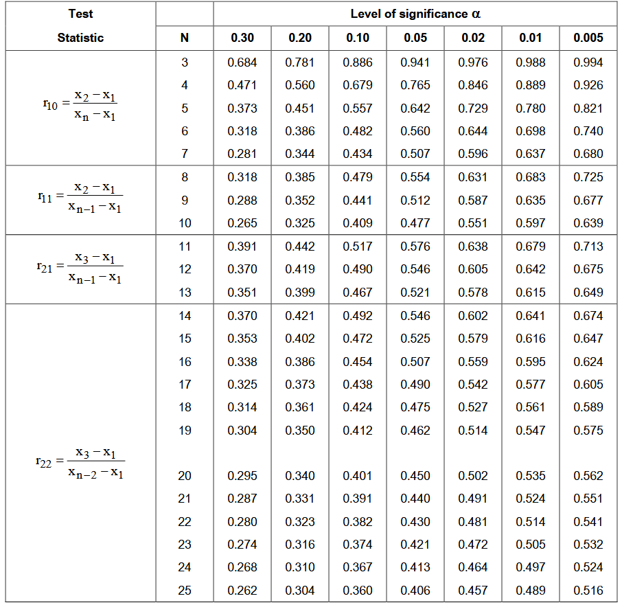

#### (5) Appliance

*USArrests* is too big a sample to apply Dixon’s tests. We can expect these tests to come in handy especially for small sized experiments such as in the area of chemistry.

### 8) Wrap up

There are many statistical methods to detect outliers, yet more beyond what we looked into in this study note. But there is no one best method. Each method is built on different assumptions and approaches. There could be improvements and pros and cons between the methods, but in the end, which to use would be more of about taste and circumstances.

In that sense, the simple yet reasonable the IQR method might be the best choice for most cases. Nonparametric, intuitive, easy to apply and visualize – these features are what make the IQR method very powerful.

## 4. For High Dimensional Data

So far, the outlier detection methods we looked into deal with univariate data sets. Then, how do we do so for higher dimensional data?

There will be various elaborate methods, of course. But to utilize the methods we studied so far, we can consider bringing the high dimensional data down to one-dimension and apply the aforementioned methods. [^13]

The job is done threefolds:

1. Dimension reduction through **PCA**: PCA(Principle Component Analysis) combines variables into new PCA variable in a way that the variations in a data set is best described. As a result, we can expect the first PCA variable to explain better than any of existing variables. Using only this first PCA variable turns the data set into a univariate one.
2. Probability estimate through **KDE**: KDE(Kernel Density Estimate) is a powerful, nonparametric way of estimating the distribution of a data set. With its result, we can right away cull out the outliers based on the probabilities. Or, we can move onto the next step.
3. Apply outlier detection algorithm: We can apply any outlier detection algorithm for the now univariate data set, be it quantile based or statistical test.

Let’s practice this method with the example data.

```r
# PCA
x = scale(data)
pca = prcomp(x)
pc1 = pca$x[, 1] # first PCA variable
cumsum(pca$sdev) / sum(pca$sdev) # cumulative variance explained by pca variables
```

```
## [1] 0.4395018 0.7171403 0.8837813 1.0000000
```

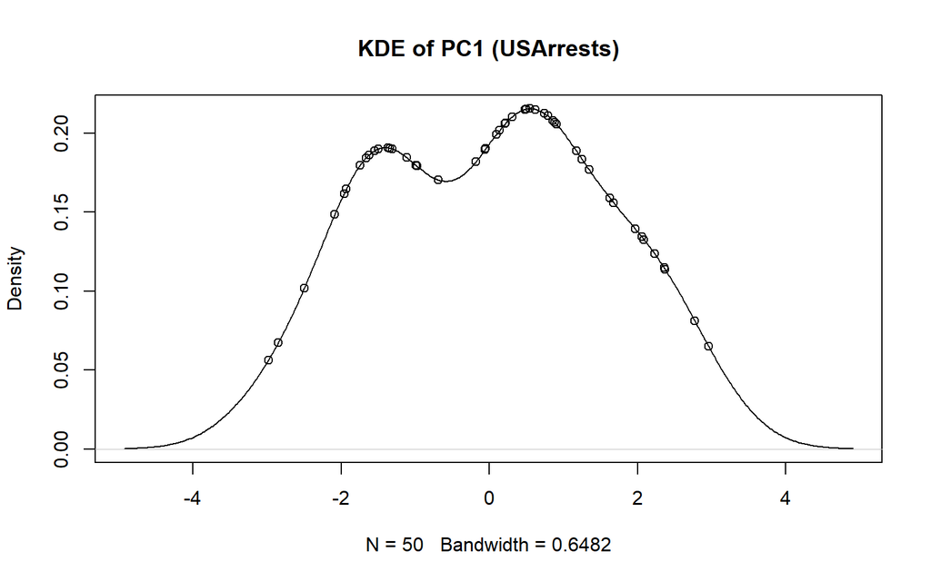

```r
# KDE
dx = density(pc1) # estimated density
pdf = approxfun(dx) # estimated density function

plot(dx, main = "KDE of PC1 (USArrests)")
points(pc1, pdf(pc1))
```

We can now apply any of the methods we dealt so far. Let’s use the simple IQR method here.

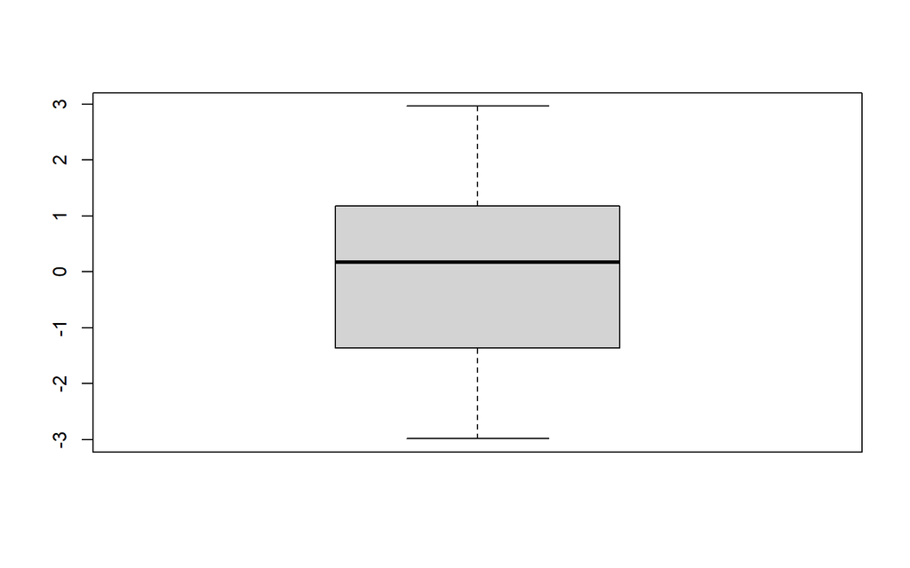

```r
boxplot(pc1, outline = T)
```

From boxplot and IQR method, no outlier is detected. That is, with multiple variables considered at the same time, no observation really stands out.

# IV. What to do with them

- **Retain**: Outliers should not be automatically excluded, for they may contain meaningful information. Especially for large sample, some number of outliers are expected.  
  On the other hand, for smaller sample, outliers may stand out more, but removing them will lead to bigger information loss. Also, doing so can be seen as fabrication for more favorable results. For this reason, some even insist that outliers should *never* be rejected.  
  Either the case, if we decided to retain the outliers, we should proceed with a model robust to outliers.
  - Running analyses with and without outliers and presenting the results for both cases might contribute to the reliability of final analysis.
- **Exclude**: If an outlier seems to be purely from error, we can simply exclude it from the data. This will likely enhance the performance of, say, a prediction model. Yet, we should reconsider if the outlier is more than just an error, even after the exclusion.
- **Check distribution assumptions**: Whether an observation is an outlier may depend on which distribution we assume. Unless we are very sure, we should check again and consider altering the underlying assumptions.
- **Replace**: For a small-sized sample, removing outliers may lead to (relatively) significant loss of information. A workaround is to replace the outliers with *reasonable* values.
  - One way to do this is **Winsorization**. If we decided to regard those beyond 95% quantile as outliers, we can replace them to the value of 95% quantile.

# Reference

- Cimbala, J. M. (2011, September 12). Outliers. Penn State University.
- Dean, R. B., and Dixon, W. J. (1951). Simplified Statistics for Small Numbers of Observations. Analytical Chemistry, 23(4), 636-638.
- Iglewicz, B., and Hoaglin, D.. (1993). How to Detect and Handle Outliers. ASQC Quality Press. Kamalov, F., & Leung, H. H. (2019). Outlier Detection in High Dimensional Data. CoRR, abs/1909.03681. Retrieve from http://arxiv.org/abs/1909.03681
- Kanji, G. K. (1993). 100 Statistical Tests. London : SAGE Publication Ltd.
- Lin, L., and Sherman, P. (2007). Cleaning Data the Chauvenet Way. SESUG 2007: The Proceedings of the SouthEast SAS Users Group.
- Mathuranathan. (2020, July 29). Q function and error functions : Demystified. GaussianWaves. Retrieved January 24, 2022, from https://www.gaussianwaves.com/2012/07/q-function-and-error-functions/
- NIST/SEMATECH. (2012a). 1.3.5.17.1. Grubbs’ Test for Outliers. e-Handbook of Statistical Methods. Retrieved January 27, 2022 from https://www.itl.nist.gov/div898/handbook/eda/section3/eda35h1.htm
- NIST/SEMATECH. (2012b). 1.3.5.17.2. Tietjen-Moore Test for Outliers. e-Handbook of Statistical Methods. Retrieved January 27, 2022 from https://www.itl.nist.gov/div898/handbook/eda/section3/eda35h2.htm
- NIST/SEMATECH. (2012c). 1.3.5.17.3. Generalized ESD Test for Outliers. e-Handbook of Statistical Methods. Retrieved January 28, 2022 from https://www.itl.nist.gov/div898/handbook/eda/section3/eda35h3.htm
- Rosner, B. (May 1983). Percentage Points for a Generalized ESD Many-Outlier Procedure. Technometrics, 25(2), 165-172.
- Ross, S. (2003). Peirce’s criterion for the elimination of suspect experimental data. J. Eng. Technol.. 20.
- Tietjen, G. L., and Moore, R. H. (1972). Some Grubbs-Type Statistics for the Detection of Several Outliers. Technometrics, 14(3), 583–597. https://doi.org/10.2307/1267287
[^1]: Iglewicz & Hoaglin, 1993
[^2]: Lin & Sherman, 2007
[^3]: Mathuranathan, 2020
[^4]: Some insist the procedure should be done only one time, for only one outlier detection.
[^5]: Ross, 2003
[^6]: Ross, 2003
[^7]: Cimbala, 2011
[^8]: NIST/SEMATECH, 2012a
[^9]: Tietjen & Moore, 1972
[^10]: NIST/SEMATECH, 2012c
[^11]: Rosner, 1983
[^12]: Kanji, 1993
[^13]: Kamalov & Leung, 2019